# Power and cost: persuasion experiment

Design and statistics follow Röttger et al.’s [*ai-distortion*](https://github.com/paul-rottger/ai-distortion) persuasion follow-up (Study 5); the model is refit here and validated against their committed results (Appendix A).

## 1. Model and assumptions

**Statistical model** (identical to Paul’s `persuasion_regressions_full_analyses.R`):

$$\text{stance\_shift} \;\sim\; \text{arm}
\;+\; (1\mid\text{reader}) \;+\; (1\mid\text{proposition})$$

a Gaussian linear mixed model (`glmmTMB`), crossed random **intercepts** for reader and proposition (no random slopes, as preregistered). The outcome is the signed attitude change toward the proposition, $\text{attitude}_\text{post}-\text{attitude}_\text{pre}$, on the 0–100 scale. A *for* summary shifts it by $+\delta$, an *against* summary by $-\delta$, a *neutral* summary by 0.

**Inference** (Paul’s): an average marginal effect (AME) is computed with `marginaleffects::avg_comparisons` (delta method, `re.form = NA`) and **detected when its 95% Wald CI excludes 0** — exactly as in Röttger et al.’s Figure 5.

**Two experimental designs**, both 6 paragraphs per participant, within-participant:

| design | arms | per arm | contrast (AME) | contrast value |
| --- | --- | --- | --- | --- |
| **3-arm** | against / neutral / for | 2 | for vs neutral | $\delta$ |
| **2-arm** | against / for | 3 | for vs against | $2\delta$ |

$\delta$ is the per-arm shift (a biased summary’s pull toward its stance). The 2-arm contrast is $2\delta$ under symmetric arms.

**Proposition pool.** 12 propositions (selection rule in §3).

**Power.** 90% power, two-sided $\alpha = 0.05$. The contrast SE is simulated under the model above with the fitted variance components over the 12-proposition pool; it scales as $SE(N)=se_\text{unit}/\sqrt{N_\text{readers}}$, so $n=\big((z_{1-\alpha/2}+z_\text{power})\,se_\text{unit}/\text{AME}\big)^2$.

**Cost model** (Paul’s): £12 per rater-hour (£9 + 33% Prolific fee); 1.5 min per paragraph + 2.5 min fixed overhead per rater. Both designs are 6 paragraphs $\Rightarrow$ £2.30 per rater.

```
## 39,980 reader-paragraph rows | 7,996 readers | 98 propositions
```

## 2. Variance components and contrast standard errors

The RQ2 model is refit (full validation in Appendix A); its variance components feed the power simulation.

```r
d2 <- df %>% filter(!is.na(stance_shift), !is.na(condition5))
m2 <- glmmTMB(stance_shift ~ condition5 + (1 | reader_id) + (1 | proposition_id),
              data = d2, family = gaussian())
vc <- VarCorr(m2)$cond
varcomp <- list(reader_sd = as.numeric(attr(vc$reader_id, "stddev")),
                prop_sd   = as.numeric(attr(vc$proposition_id, "stddev")),
                resid_sd  = sigma(m2))
tibble(component = c("reader", "proposition", "residual", "marginal"),
       sd = c(varcomp$reader_sd, varcomp$prop_sd, varcomp$resid_sd,
              sqrt(varcomp$reader_sd^2 + varcomp$prop_sd^2 + varcomp$resid_sd^2))) %>%
  kable(digits = 3)
```

| component | sd |
| --- | --- |
| reader | 2.937 |
| proposition | 1.924 |
| residual | 15.866 |
| marginal | 16.250 |

```r
set.seed(1)
SE_3 <- simulate_ame_se_unit(varcomp, arms = c("neutral", "for", "against"),
                             qpa = 2, contrast = c("neutral", "for"))$se_unit
SE_2 <- simulate_ame_se_unit(varcomp, arms = c("against", "for"),
                             qpa = 3, contrast = c("against", "for"))$se_unit
tibble(design = c("3-arm (for vs neutral, 2/arm)", "2-arm (for vs against, 3/arm)"),
       se_unit = c(SE_3, SE_2)) %>% kable(digits = 2)
```

| design | se_unit |
| --- | --- |
| 3-arm (for vs neutral, 2/arm) | 15.84 |
| 2-arm (for vs against, 3/arm) | 12.94 |

The simulated AME SE equals the `glmmTMB` coefficient SE (identical to $10^{-6}$), so the uncertainty driving the power calculation is computed exactly as in Appendix A. Direct check (3-arm): at the N predicted for 90% power at $\delta = 3$ (N $\approx$ 293), 200 simulated experiments have the AME 95% CI exclude 0 in 92% of cases.

## 3. Proposition selection

Two per-proposition metrics, averaged over Paul’s treated documents (95% CIs = mean ± 1.96·SE, SE = sd/√n; within a proposition each reader contributes one rating, so ratings are ~independent):

- **oriented belief shift** — movement in the direction the document advocates, $\text{sign}(\text{perceived\_stance}-50)\times(\text{attitude}_\text{post}-\text{attitude}_\text{pre})$, using the **perceived (annotator-labelled) stance** for orientation and **excluding documents with perceived stance in [40, 60]** (no clear advocated direction);
- **non-oriented belief shift** — net movement regardless of the document’s persuasive intent, $\text{attitude}_\text{post}-\text{attitude}_\text{pre}$ averaged over all treated documents (a proposition where readers all drift the same way irrespective of the paragraph is undesirable).

**Selection rule.** A desirable proposition has **high oriented** belief shift, **low non-oriented** belief shift (in absolute value), and **high average bias**. Each metric is converted to a rank across propositions; the non-oriented rank is inverted (lower is better); the ranks are summed; and the **top 6 left- and top 6 right-coded** propositions by summed rank are selected (12 total). Bias is not yet available, so it is currently omitted. For conservative estimates the **95% CI endpoints** are used: the **lower** bound of the oriented shift and the **|·| of the non-oriented CI endpoint furthest from 0** (= $|\text{non-oriented}| + 1.96\,\text{SE}$).

```r
feats <- proposition_features(DATA)
pm <- df %>% filter(!is_control) %>%
  mutate(raw = pa_post - pa_pre,
         oriented_obs = if_else(writer_stance < 40 | writer_stance > 60,
                                sign(writer_stance - 50) * raw, NA_real_)) %>%
  group_by(proposition_id) %>%
  summarise(oriented      = mean(oriented_obs, na.rm = TRUE),
            oriented_se   = sd(oriented_obs, na.rm = TRUE) / sqrt(sum(!is.na(oriented_obs))),
            agreement     = mean(raw, na.rm = TRUE),
            agreement_se  = sd(raw, na.rm = TRUE) / sqrt(n()),
            .groups = "drop") %>%
  filter(is.finite(oriented)) %>%
  left_join(feats %>% select(proposition_id, proposition_leaning), by = "proposition_id") %>%
  mutate(x_lo = oriented - 1.96 * oriented_se,  x_hi = oriented + 1.96 * oriented_se,
         y_lo = agreement - 1.96 * agreement_se, y_hi = agreement + 1.96 * agreement_se,
         oriented_cons     = x_lo,                              # conservative oriented (lower CI bound)
         nonoriented_cons  = pmax(abs(y_lo), abs(y_hi)),        # conservative |non-oriented| (furthest endpoint)
         rank_oriented     = rank(oriented_cons),               # higher = better
         rank_nonoriented  = rank(-nonoriented_cons),           # inverted: lower |non-oriented| = better
         score             = rank_oriented + rank_nonoriented)  # (+ bias rank, once available)

selected <- pm %>% filter(proposition_leaning %in% c("left", "right")) %>%
  group_by(proposition_leaning) %>% slice_max(score, n = 6, with_ties = FALSE) %>% ungroup()
pm <- pm %>% mutate(selected = proposition_id %in% selected$proposition_id)

selected %>% arrange(proposition_leaning, desc(score)) %>%
  transmute(proposition_id, proposition_leaning,
            oriented_cons = round(oriented_cons, 2), nonoriented_cons = round(nonoriented_cons, 2),
            rank_oriented, rank_nonoriented, score) %>%
  kable()
```

| proposition_id | proposition_leaning | oriented_cons | nonoriented_cons | rank_oriented | rank_nonoriented | score |
| --- | --- | --- | --- | --- | --- | --- |
| 82 | left | 6.19 | 2.20 | 91 | 87 | 178 |
| 87 | left | 4.44 | 1.93 | 80 | 92 | 172 |
| 384 | left | 4.67 | 2.39 | 83 | 83 | 166 |
| 333 | left | 4.27 | 2.25 | 78 | 85 | 163 |
| 392 | left | 3.91 | 2.03 | 71 | 88 | 159 |
| 389 | left | 8.72 | 3.88 | 96 | 54 | 150 |
| 264 | right | 4.54 | 2.02 | 81 | 89 | 170 |
| 38 | right | 8.98 | 3.09 | 97 | 72 | 169 |
| 89 | right | 5.77 | 3.48 | 90 | 65 | 155 |
| 184 | right | 3.39 | 1.97 | 64 | 90 | 154 |
| 22 | right | 5.35 | 3.69 | 88 | 60 | 148 |
| 230 | right | 3.62 | 2.56 | 66 | 80 | 146 |

Each point is a proposition (coloured by leaning) with 95% CIs in both directions; circled points are the 12 selected.

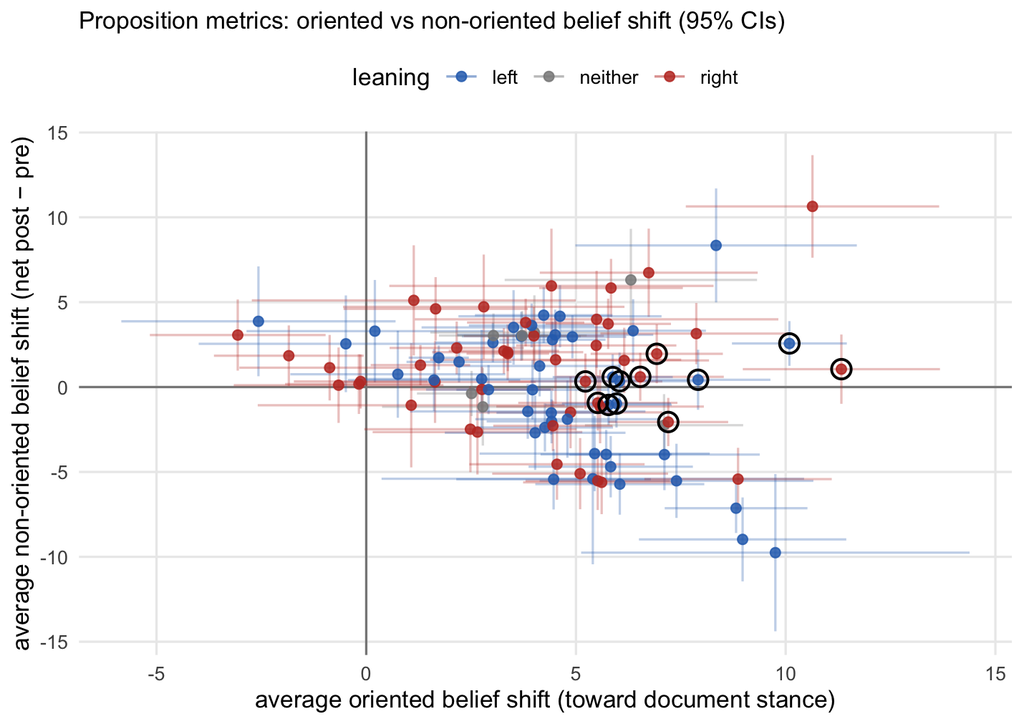

## 4. Power and cost: 3-arm vs 2-arm

Total cost to detect a per-arm shift $\delta$ at 90% power (two-sided $\alpha = 0.05$), for both designs. The 3-arm design detects the for-vs-neutral AME ($\delta$); the 2-arm design detects the for-vs-against AME ($2\delta$).

```r
designs <- list(
  list(label = "3-arm (for vs neutral)", se_unit = SE_3, mult = 1, questions = 6),
  list(label = "2-arm (for vs against)", se_unit = SE_2, mult = 2, questions = 6)
)
cost_table(deltas = c(1, 2, 5, 10), designs = designs) %>%
  select(design, delta, n_raters, total_cost_gbp) %>%
  pivot_wider(names_from = design, values_from = c(n_raters, total_cost_gbp)) %>%
  kable()
```

| delta | n_raters_3-arm (for vs neutral) | n_raters_2-arm (for vs against) | total_cost_gbp_3-arm (for vs neutral) | total_cost_gbp_2-arm (for vs against) |
| --- | --- | --- | --- | --- |
| 1 | 2638 | 440 | 6067 | 1012 |
| 2 | 660 | 110 | 1518 | 253 |
| 5 | 106 | 18 | 244 | 41 |
| 10 | 27 | 5 | 62 | 12 |

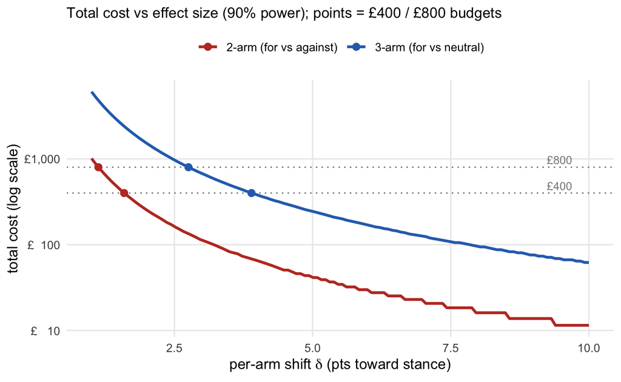

Per-arm shift detectable at each budget (where the curves meet the budget lines):

| design | budget_gbp | min_detectable_delta |
| --- | --- | --- |
| 2-arm (for vs against) | 400 | 1.59 |
| 3-arm (for vs neutral) | 400 | 3.89 |
| 2-arm (for vs against) | 800 | 1.12 |
| 3-arm (for vs neutral) | 800 | 2.75 |

## 5. Paul’s analysis on £400 / £800 of data

Empirical complement to §4: re-run Paul’s exact RQ1 analysis (`stance_shift ~ paragraph_type + (1|reader) + (1|proposition)`) on random subsamples of his data sized to a £400 and £800 budget. At Paul’s per-rater cost (5 paragraphs = £2.00), £400 buys 200 readers and £800 buys 400 readers. Each budget is resampled 50 times; readers are the sampling unit.

Each treated arm’s mean shift is tested **against 0** (its `avg_predictions` marginal mean, not a contrast against the control arm); the AI-vs-human contrast is also reported.

```r
PAUL_RATER <- cost_per_rater(5)                 # Paul's design: 5 paragraphs/rater
budgets <- c(400, 800)
n_by_budget <- setNames(round(budgets / PAUL_RATER), paste0("£", budgets))
TERMS <- c("AI (vs 0)", "human (vs 0)", "AI vs human")
res <- bind_rows(lapply(seq_along(budgets), function(i)
  rerun_subsample(df, n_readers = n_by_budget[i], reps = 50, seed0 = 1000 * i) %>%
    mutate(budget = paste0("£", budgets[i]), n_readers = n_by_budget[i])))

res %>% group_by(budget, n_readers, term) %>%
  summarise(median_AME = median(est), median_CI_low = median(lo), median_CI_high = median(hi),
            pct_CI_excludes_0 = round(100 * mean(excludes0)), .groups = "drop") %>%
  arrange(match(term, TERMS), n_readers) %>%
  kable(digits = 2)
```

| budget | n_readers | term | median_AME | median_CI_low | median_CI_high | pct_CI_excludes_0 |
| --- | --- | --- | --- | --- | --- | --- |
| £400 | 200 | AI (vs 0) | 4.18 | 2.52 | 5.82 | 100 |
| £800 | 400 | AI (vs 0) | 4.29 | 3.14 | 5.37 | 100 |
| £400 | 200 | human (vs 0) | 2.84 | 1.17 | 4.46 | 98 |
| £800 | 400 | human (vs 0) | 2.78 | 1.59 | 3.92 | 98 |
| £400 | 200 | AI vs human | 1.28 | -0.89 | 3.55 | 20 |
| £800 | 400 | AI vs human | 1.61 | 0.03 | 3.07 | 50 |

`pct_CI_excludes_0` is the share of random subsamples in which the 95% Wald CI clears 0 — the realised detection rate at that budget on real data.

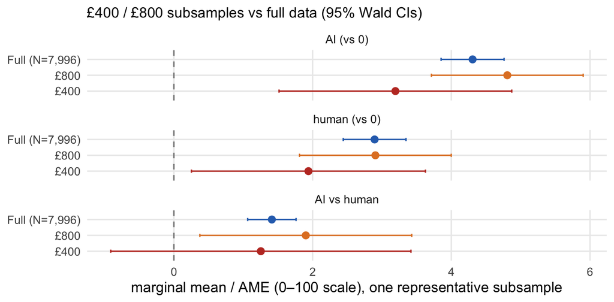

## 6. Secondary analysis: persuasion by document stance

Persuasive (treated) documents are split by their **writer-labelled stance** — the writer’s own pre-stance from the main study (`writer_stance_pre`, 0–100): *for* (> 50) vs *against* (< 50). The outcome is the raw signed attitude change toward the proposition, $\text{attitude}_\text{post}-\text{attitude}_\text{pre}$, modelled as `raw_shift ~ doc_stance + (1|reader) + (1|proposition)`; the marginal mean shift of each group is reported with its 95% Wald CI.

```r
pr_self <- read_csv(file.path(DATA, "main_phase_1/proposition_responses.csv"), show_col_types = FALSE) %>%
  transmute(writer_id = as.character(writer_id), proposition_id = as.character(proposition_id),
            writer_stance_pre)
treated <- df %>% filter(!is_control) %>%
  left_join(pr_self, by = c("writer_id", "proposition_id")) %>%
  filter(!is.na(writer_stance_pre), writer_stance_pre != 50) %>%
  mutate(doc_stance = if_else(writer_stance_pre > 50, "for", "against"),
         raw_shift  = pa_post - pa_pre)
ms <- glmmTMB(raw_shift ~ doc_stance + (1 | reader_id) + (1 | proposition_id),
              data = treated, family = gaussian())
counts <- treated %>% count(doc_stance, name = "n_ratings")
avg_predictions(ms, by = "doc_stance", type = "response", re.form = NA) %>%
  as_tibble() %>%
  transmute(doc_stance, mean_raw_shift = estimate, conf.low, conf.high) %>%
  left_join(counts, by = "doc_stance") %>%
  kable(digits = 2)
```

| doc_stance | mean_raw_shift | conf.low | conf.high | n_ratings |
| --- | --- | --- | --- | --- |
| against | -3.27 | -3.97 | -2.57 | 14660 |
| for | 4.03 | 3.32 | 4.73 | 14083 |

A *for* document moves attitudes toward the proposition (positive raw shift); an *against* document moves them away (negative). The magnitudes index the per-arm shift $\delta$ in each direction (the symmetry assumed by the 2-arm design in §4).

Distribution of the writer-labelled stance of the 800 distinct documents Paul showed to persuasion participants:

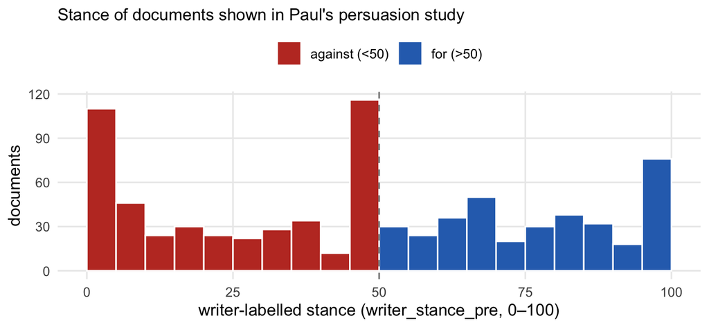

### Granular stance–response (non-linearity)

The for/against split above is coarsened to one cut at 50. Here the document stance enters more granularly, measured **two ways separately**: the **writer-labelled** stance (`writer_stance_pre`) and the **annotator-labelled** stance (the perceived `writer_stance` from the main-study annotations). Outcome is the raw signed shift toward the proposition. Each stance is (a) bucketed into deciles, fit as `raw_shift ~ bucket + (1|reader) + (1|proposition)` (per-decile marginal mean), and (b) entered as a natural cubic spline `ns(stance, 4)` for a smooth fit.

```r
treated_g <- df %>% filter(!is_control) %>%
  left_join(pr_self, by = c("writer_id", "proposition_id")) %>%
  mutate(raw_shift = pa_post - pa_pre)
sr_writer <- stance_response(treated_g %>% transmute(raw_shift, stance = writer_stance_pre, reader_id, proposition_id))
sr_annot  <- stance_response(treated_g %>% transmute(raw_shift, stance = writer_stance,     reader_id, proposition_id))
buckets <- bind_rows(sr_writer$buckets %>% mutate(source = "writer-labelled"),
                     sr_annot$buckets  %>% mutate(source = "annotator-labelled"))
spline  <- bind_rows(sr_writer$spline %>% mutate(source = "writer-labelled"),
                     sr_annot$spline  %>% mutate(source = "annotator-labelled"))
buckets %>% transmute(source, stance_bucket = bucket, mid, mean_raw_shift = estimate,
                      conf.low, conf.high, n) %>%
  arrange(source, mid) %>% kable(digits = 2)
```

| source | stance_bucket | mid | mean_raw_shift | conf.low | conf.high | n |
| --- | --- | --- | --- | --- | --- | --- |
| annotator-labelled | [0,10] | 5 | -5.78 | -6.65 | -4.91 | 3225 |
| annotator-labelled | (10,20] | 15 | -5.70 | -6.48 | -4.92 | 4503 |
| annotator-labelled | (20,30] | 25 | -3.80 | -4.64 | -2.95 | 3435 |
| annotator-labelled | (30,40] | 35 | -3.00 | -3.95 | -2.06 | 2147 |
| annotator-labelled | (40,50] | 45 | -1.31 | -2.18 | -0.44 | 3045 |
| annotator-labelled | (50,60] | 55 | 0.54 | -0.42 | 1.50 | 2032 |
| annotator-labelled | (60,70] | 65 | 3.11 | 2.12 | 4.09 | 1914 |
| annotator-labelled | (70,80] | 75 | 3.96 | 3.02 | 4.91 | 2209 |
| annotator-labelled | (80,90] | 85 | 5.98 | 5.20 | 6.75 | 4573 |
| annotator-labelled | (90,100] | 95 | 6.18 | 5.41 | 6.96 | 4901 |
| writer-labelled | [0,10] | 5 | -5.16 | -5.99 | -4.33 | 6191 |
| writer-labelled | (10,20] | 15 | -4.28 | -5.32 | -3.24 | 2197 |
| writer-labelled | (20,30] | 25 | -3.97 | -5.07 | -2.87 | 1857 |
| writer-labelled | (30,40] | 35 | -1.27 | -2.28 | -0.27 | 2442 |
| writer-labelled | (40,50] | 45 | -0.05 | -0.88 | 0.78 | 5214 |
| writer-labelled | (50,60] | 55 | 1.81 | 0.76 | 2.86 | 2104 |
| writer-labelled | (60,70] | 65 | 4.12 | 3.20 | 5.04 | 3475 |
| writer-labelled | (70,80] | 75 | 5.00 | 3.93 | 6.07 | 1969 |
| writer-labelled | (80,90] | 85 | 5.35 | 4.37 | 6.34 | 2704 |
| writer-labelled | (90,100] | 95 | 4.98 | 4.06 | 5.90 | 3831 |

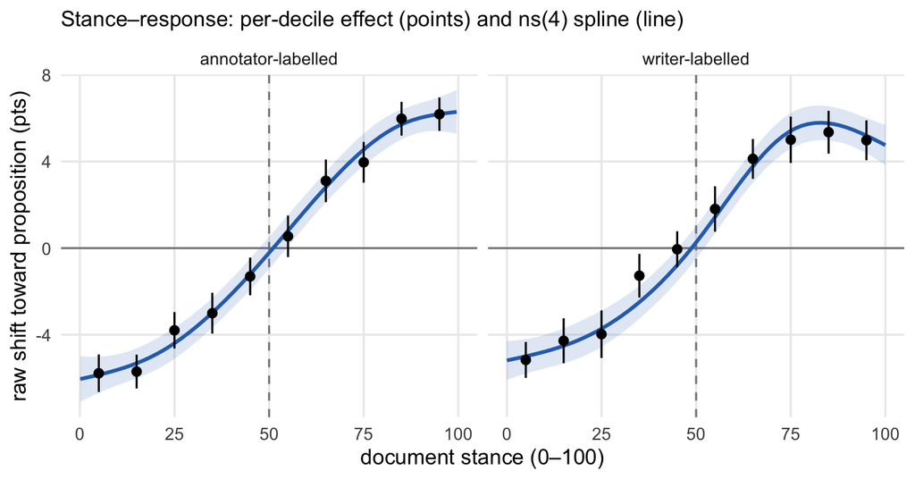

## Appendix A: Validation against Paul’s data

Point estimates, **standard errors and 95% CIs** for the average marginal effects and condition means are computed with `marginaleffects` (delta method, `re.form = NA`) — Paul’s exact procedure — and compared with the values committed in `results/followup_persuasion`. (His SE is recovered as estimate/z for the AMEs and CI-width$/2z_{.975}$ for the condition means.)

```r
if (!exists("m1")) {                            # m1 is fit in §5; reuse it
  d1 <- df %>% filter(!is.na(stance_shift), !is.na(paragraph_type3))
  m1 <- glmmTMB(stance_shift ~ paragraph_type3 + (1 | reader_id) + (1 | proposition_id),
                data = d1, family = gaussian())
}
ac_ref  <- avg_comparisons(m1, variables = list(paragraph_type3 = "reference"),
                           type = "response", re.form = NA)
ac_pair <- avg_comparisons(m1, variables = list(paragraph_type3 = c("human", "ai")),
                           type = "response", re.form = NA)
preds   <- avg_predictions(m2, by = "condition5", type = "response", re.form = NA)
```

| quantity | estimate | se | ci_low | ci_high | paul_est | paul_se | \|d est\| | \|d SE\| | \|d CI\| |
| --- | --- | --- | --- | --- | --- | --- | --- | --- | --- |
| AME: AI vs control | 4.3254 | 0.2180 | 3.8980 | 4.7528 | 4.3254 | 0.2180 | 0 | 0.0000 | 0.0000 |
| AME: human vs control | 2.9127 | 0.2180 | 2.4854 | 3.3400 | 2.9127 | 0.2180 | 0 | 0.0000 | 0.0000 |
| AME: AI vs human | 1.4127 | 0.1780 | 1.0639 | 1.7616 | 1.4127 | 0.1780 | 0 | 0.0000 | 0.0000 |
| mean shift: control | -0.0128 | 0.2684 | -0.5389 | 0.5133 | -0.0128 | 0.2684 | 0 | 0.0000 | 0.0000 |
| mean shift: human-low | 4.4489 | 0.2709 | 3.9179 | 4.9799 | 4.4489 | 0.2715 | 0 | 0.0006 | 0.0011 |
| mean shift: human-high | 1.3491 | 0.2708 | 0.8183 | 1.8799 | 1.3491 | 0.2706 | 0 | 0.0003 | 0.0005 |
| mean shift: ai-low | 4.4098 | 0.2706 | 3.8794 | 4.9401 | 4.4098 | 0.2722 | 0 | 0.0016 | 0.0032 |
| mean shift: ai-high | 4.2148 | 0.2700 | 3.6855 | 4.7440 | 4.2148 | 0.2698 | 0 | 0.0003 | 0.0005 |

Condition means with Paul’s model 95% CIs (`avg_predictions`):

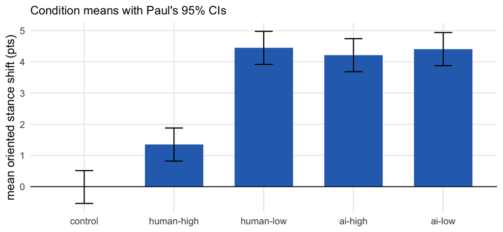

Reproduction of **Figure 5B** (AI-vs-human AME in stance shift, overall and by persona distortion, 95% Wald CIs against the “no AI advantage” line):

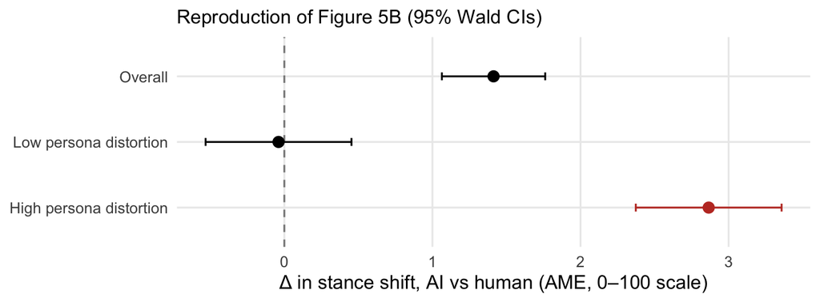

Mean oriented stance shift by presentation position (positions randomised):

| order | mean | sd | n |
| --- | --- | --- | --- |
| 1 | 3.56 | 18.88 | 6347 |
| 2 | 3.29 | 17.17 | 6411 |
| 3 | 3.59 | 16.77 | 6417 |
| 4 | 3.75 | 16.18 | 6363 |
| 5 | 3.62 | 16.12 | 6446 |